# Week 5: Pizzaria a la Paulie

Shyni David

```r
library(tidyverse)
```

# Part 1: Paulie’s Pizzeria: Time to expand?

According to Tom Larkin in his article, “8 Factors for Choosing a New Restaurant Location,” the number 1 requirement is visibility. He advises “to determine visibility, look at foot and car traffic patterns.” Who’s walking by? Who’s driving by? And of course, not only “who” matters, but also “how many.”

Tony Soprano is considering opening a new franchise in New Jersey called Paulie’s Pizzaria. Based on financial analyses, the site is acceptable only if the number of pedestrians passing the location averages more than 100 per hour. To determine if this site is acceptable, Tony hired a consulting firm to help with the collection and analysis of sample data. The consulting firm arranged for the number of pedestrians for each of 40 randomly selected hours to be observed and recorded. This data can be found on the web and can be downloaded with the following code.

```r
ped <- read_csv("https://raw.githubusercontent.com/jddbucknole/SMB-A/master/week5PauliesPizza.csv")
```

Unfortunately, the consulting company reneged on the analysis phase of the project. Your team has been hired to complete the necessary analysis of the data. Tony knows very little about statistical methodology or terminology, but he knows about risk. Sal has made it clear that he is very interested in this location and doesn’t want to miss the opportunity if the site is acceptable, but he cannot afford to lose the capital investment if the restaurant fails.

## Summary Statistics

Before embarking any further, Tony would like to know some summary statistics and a simple graph showing the distribution of the number of pedestrians passing the site per hour.

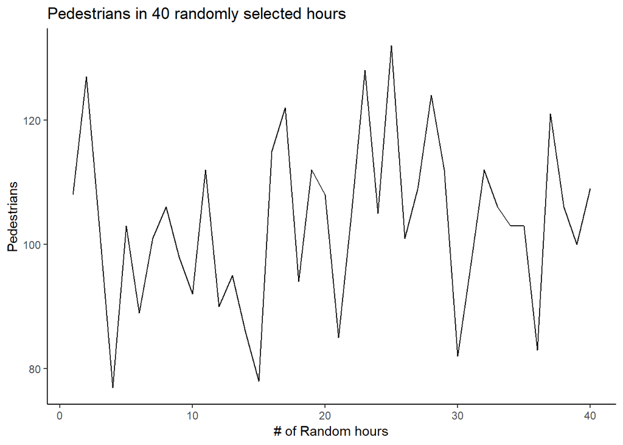

```r
#Code here examining basic summary stats and a single graph displaying the pedestrian distribution
mean <- mean(ped$Pedestrians)
StandardDeviation <- sd(ped$Pedestrians)
minimum <- min(ped$Pedestrians)
maximum <- max(ped$Pedestrians)
df<- data.frame(ped)
plotped <- cbind(hours= 1:40, df)


ggplot(data=plotped, aes(x= hours,y=Pedestrians)) + geom_line() +
     labs(title="Pedestrians in 40 randomly selected hours", x="# of Random hours", y="Pedestrians") + theme_classic()
```

## Time to test!

Formulate the appropriate hypotheses, run the test, and draw appropriate conclusions. You are in control of all specifics of the problem (i.e., choosing alpha and deciding how to manage the risks–there are no wrong answers, but you should justify your choices). Fill in your hypotheses below and make sure your conclusions are stated *in terms of the problem*.

H0:Pedestrian average is less than 100 per hour passing the location

HA:Pedestrain average is more than 100 per hour passing the location

```r
#Put additional code here to test the hypothesis.
t.test(ped$Pedestrians, mu = 100, alternative =  "greater")
```

```
##
##  One Sample t-test
##
## data:  ped$Pedestrians
## t = 1.6004, df = 39, p-value = 0.0588
## alternative hypothesis: true mean is greater than 100
## 95 percent confidence interval:
##  99.81779      Inf
## sample estimates:
## mean of x
##    103.45
```

A large p-value (> 0.05) indicates weak evidence against the null hypothesis, so we will fail to reject the null hypothesis.Since the null hypothesis says that Pedestrian average is less than 100 per hour passing the location, so he should not open the restaurant.as the site is not acceptable.

# Part 2: The current Paulie’s Pizzeria: How much are servers being tipped?

While the analysts were diligently working on discovering if the new location was viable, the employees at the current restaurant have started to complain about their tip amounts. Recent receipts have shown an average percentage tip of around 17% but the median is closer to 16%. Tony wants to get a better idea of the average percent of the bill that is being tipped. To do this, he has a sample of 157 recent bills and tip amounts. The data can be accessed below. He feels a 17% mean is ample for his employees.

```r
library(Lock5Data)
head(RestaurantTips)
```

```
##    Bill   Tip Credit Guests Day Server PctTip
## 1 23.70 10.00      n      2   f      A   42.2
## 2 36.11  7.00      n      3   f      B   19.4
## 3 31.99  5.01      y      2   f      A   15.7
## 4 17.39  3.61      y      2   f      B   20.8
## 5 15.41  3.00      n      2   f      B   19.5
## 6 18.62  2.50      n      2   f      A   13.4
```

## Make a confidence interval for the mean: the traditional way

To motivate the employees, Tony wants to give a 95% confidence interval for the average percentage of the bill that is tipped (PctTip in the RestaurantTips dataset). Visualize the PctTip via a histogram and make a 95% confidence interval for the average PctTip. You may use a built in R function or use R to calculate from the component stats.

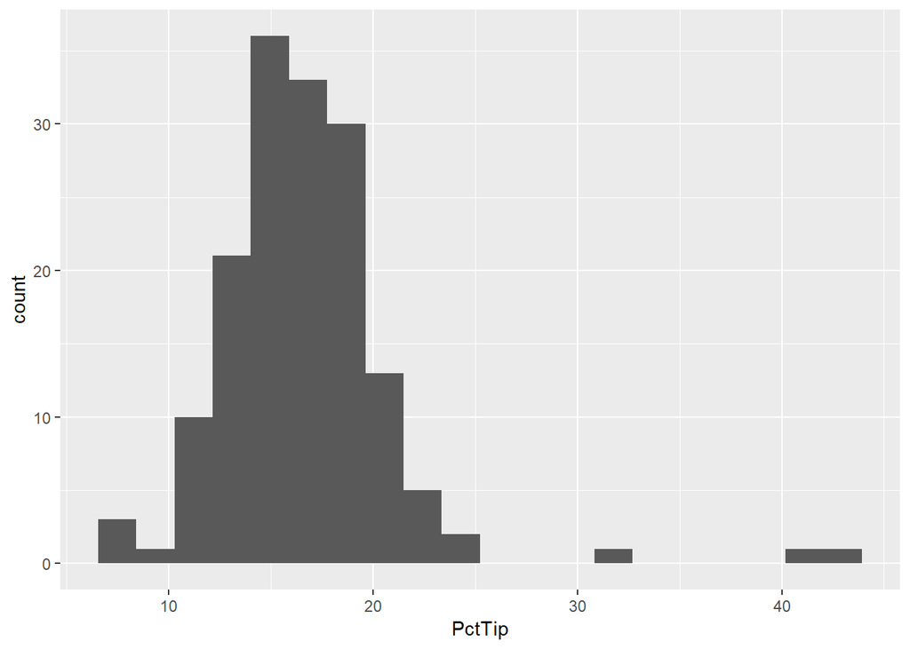

```r
ggplot(data = RestaurantTips, aes(x = PctTip)) +geom_histogram(bins=20)
```

```r
t.test(RestaurantTips$PctTip, mu = 17, conf.level = .95, alternative = "less")
```

```
##
##  One Sample t-test
##
## data:  RestaurantTips$PctTip
## t = -1.0881, df = 156, p-value = 0.1391
## alternative hypothesis: true mean is less than 17
## 95 percent confidence interval:
##      -Inf 17.19832
## sample estimates:
## mean of x
##  16.61911
```

H0= average pct tip is greater than 17 HA= average pct tip is less than or equal to 17

A large p-value (> 0.05) indicates weak evidence against the null hypothesis, so we wil fail to reject the null hypothesis.

We are justified using CI using normal methodology based on Central Limit Theorem which says that: given random and independent samples of N observations each, the distribution of sample means approaches normality as the size of N increases, regardless of the shape of the population distribution.

## Another way: Bootstrapping!

While we feel confident in using the standard normal methodology as you explained above, Tony want to get another perspective. He’s heard of a technique called Bootstrapping and wants to give it a try. The following steps will create a 95% bootstrap confidence interval.

1. Create a function called bootsample that takes a sample of equal size (n = 157) from your current sample *with replacement*. Your function should return the mean of your bootstrap sample. This is mimicking taking many samples from the population.

```r
bootsample <- function(data){

  sampleped <- sample(data, size=157, replace=TRUE)
  meansample <- mean(sampleped)
  return(meansample)
   }
```

2. Now, the goal is to repeatedly call this function with our tip percentage data and report the mean of the resamples. This is a perfect time to use the replicate() function. Create 1000 bootstrap sample means using the replicate function (refer to week 3 and 4 if you don’t remember how to do this–you can alos use the for loop, but replicate only requires one line of code). Store the means in a variable called bootmeans.

```r
bootmeans <-replicate(1000,bootsample(RestaurantTips$PctTip) )
```

3. The bootstrap means can be thought of as repeated sample means from taking multiple samples. To find a bootstrapped confidence interval, find the 0.025 and 0.975 quantile of the bootstrapped means (this interval contains the middle 95% of sample means).

```r
quantile(bootmeans, 0.025)
```

```
##     2.5%
## 15.98597
```

```r
quantile(bootmeans, 0.975)
```

```
##    97.5%
## 17.27825
```

The head waiter, Christopher, noted some outliers in the dataset and feels that the mean may not be the most fair representation of how much a server should be expecting in tip. He feels the median is a better representation of what the servers should expect but doesn’t know how to form a confidence interval of the median. While he agrees that 17% is a fair tip, he want to focus on the median, not the mean. Bootstrapping to the rescue!

```r
 bootmedian<- function(data){

  samplepe<- sample(data, size=157, replace=TRUE)
  meansample <- median(sampleped)
  return(mediansample)
 }

bootmedian <-replicate(1000,bootsample(RestaurantTips$PctTip) )
quantile(bootmedian, 0.025)
```

```
##     2.5%
## 15.96099
```

```r
quantile(bootmedian, 0.975)
```

```
##    97.5%
## 17.23726
```